# Robustness of t-test

Clay Ford

1/7/2022

Let’s simulate data similar to what you sent me via email on 2022 Jan 7.

```r
n <- 1800
# the following are based on eyeballing the plot you sent me
probs <- c(25, 50, 75, 200, 325, 225)/
  sum(c(25, 50, 75, 200, 325, 225))

ctrl <- sample(1:6, size = n/2, replace = TRUE,
               prob = probs)
intv <- sample(1:6, size = n/2, replace = TRUE,
               prob = probs)
d <- data.frame(score = c(ctrl, intv),
                group = rep(c("control", "intervention"), each = n/2))
```

Create plot

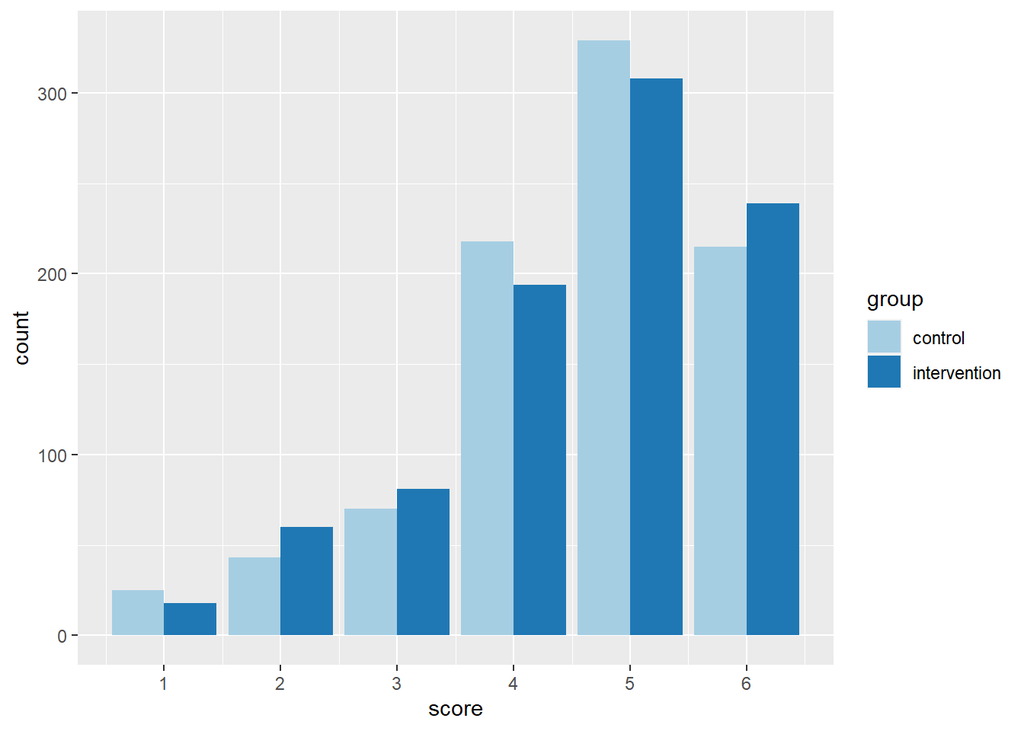

```r
library(ggplot2)
ggplot(d) +
  aes(x = score, fill = group) +
  geom_bar(position = "dodge") +
  scale_fill_brewer(palette = "Paired") +
  scale_x_continuous(breaks = 1:6)
```

Run Welch t-test

```r
t.test(score ~ group, data = d)
```

```
##
##  Welch Two Sample t-test
##
## data:  score by group
## t = -0.056867, df = 1796.2, p-value = 0.9547
## alternative hypothesis: true difference in means between group control and group intervention is not equal to 0
## 95 percent confidence interval:
##  -0.1182964  0.1116297
## sample estimates:
##      mean in group control mean in group intervention
##                   4.586667                   4.590000
```

Ideally this should FAIL TO REJECT the null of no difference between means because I simulated the data for each group from the same distribution. The p-value should be much larger than 0.05.

Now both distributions are distinctly non normal as seen in the plot above. However the t-test comparing the means between these two distributions is *robust to this assumption*. That means it still works. It should falsely reject the null of no difference only about 5% of the time.

Below we create a function that simulates two data sets from the same non-normal distribution, runs a Welch t-test, and returns TRUE if the p-value is less than 0.05, and FALSE otherwise.

```r
ttest_function <- function(n = 1800){
  ctrl <- sample(1:6, size = n/2, replace = TRUE,
               prob = probs)
  intv <- sample(1:6, size = n/2, replace = TRUE,
               prob = probs)
  d <- data.frame(score = c(ctrl, intv),
                group = rep(c("control", "intervention"), each = n/2))
  t.test(score ~ group, data = d)$p.value < 0.05
}
```

Now we replicate the function 2000 times and calculate the proportion of times it rejects the null of no difference (ie, Type 1 error, rejecting the null when it’s really true.).

```r
tests <- replicate(n = 2000, ttest_function(n = 1800))
mean(tests)
```

```
## [1] 0.0455
```

We see that it performs well and that the Type 1 error is close to 0.05 The t-test in this case is robust to departures from normality.